# Pourquoi et comment inscrire la production de cartes statistiques dans un processus de recherche reproductible

Journée cartostats - 9 juin 2017

## 1. Pourquoi ?

## Qu'est ce que la recherche reproductible ?

**La reproductibilité est le meilleur test de la validité d'une expérimentation scientifique**

**La science est infaillible ; mais les savants se trompent toujours" (Anatole France, 1889)**

**BUT : Accompagner les publications scientifiques des jeux de données et codes sources pour permettre aux collègues de reproduire les résultats**

## Intérêt de la recherche reproductible

Peng, 2011

## Et les cartes ?

**Les cartes, comme les autres production graphiques ou statistiques sont des éléments à part entière des études scientifique**

**La grande majorité des cartes produites dans un contexte académique actuellement sont produite en utilisant une grande variété de logiciel et de formats**

**Cette variété de formats et de logiciel rend difficile la reproduction des cartes**

## Les enjeux de la cartographie reproductible

- Garder une trace des traitements effectuer
- Partager ses méthodes
- Etre transparent, s'exposer à la critique
- Faciliter les mises à jour
- Travailler collectivement
- Automatisation des taches
- Lier fortement l'analyse et la représentation

## Cartographie reproductible

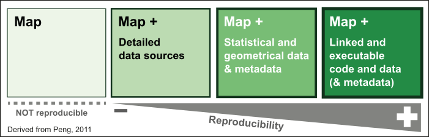

## Quels objectifs et quels critères pour choisir les bons outils

- Disponibilité (question du coût des licences)
- Transparence (open-source, licence d'utilisation)
- Simplicité d'utilisation (degrès d'adoption de la solution dans la communauté concernée)

## Un jeu d'outils et de technologies

- Pouvoir mettre en oeuvre un grand nombre de traitements, de méthodes et de représentations stat/spatials dans un même environnement.  
  **==> Le logiciel R, son ecosystème de package et un IDE.**
- Pouvoir présenter ses résultats de manière à permettre leur reproduction  
  **==> Des solutions de *literate programming*, tel que le markdown et le RMardown.**
- Diffuser et partager ses résultats, éventuellement travailler en équipe ou faire appel à des contributeurs.  
  **==> Un logiciel de gestion de version, tel que git et la plateforme d'hébergement Github basé sur celui-ci.**

## Simplifier les chaines de traitement

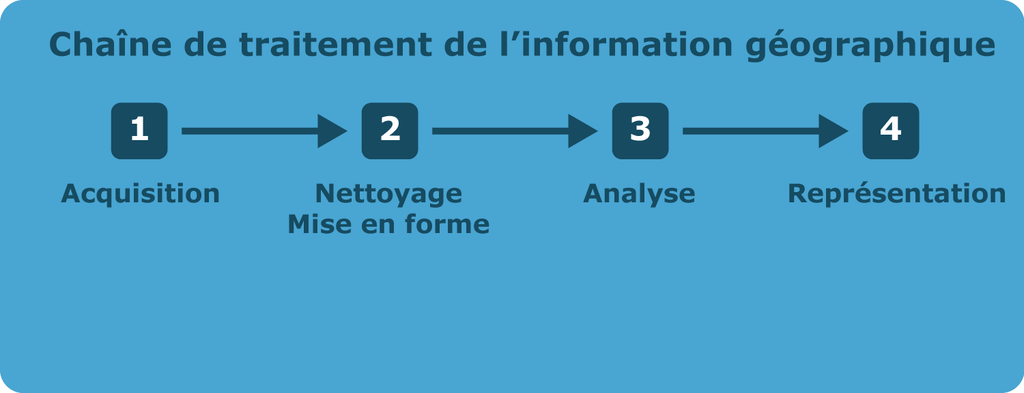

## Simplifier les chaines de traitement

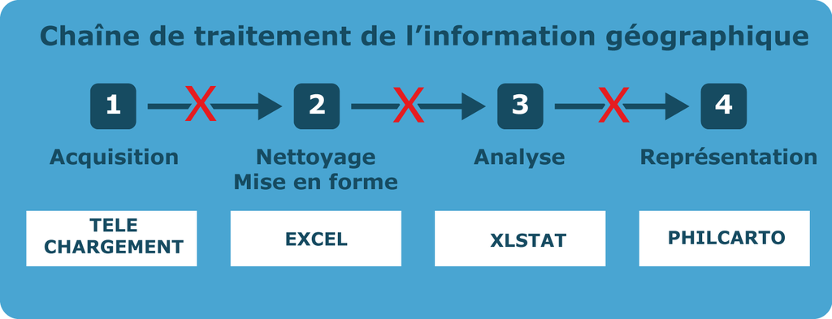

## Simplifier les chaines de traitement

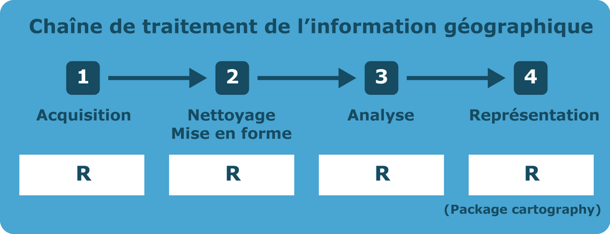

### R et son ecosystème

### Le literate programming

### Les logiciels de gestion de version

## 3. Le package cartography

## Un jeu de fonctions simples et configurables

## Des représentations classiques…

## … et des représentations plus complexes

## 4. Exemple d'application

## Analyse du vote en faveur de Jean-Luc Mélenchon en Île-de-France.

- Extraction des données
- Nettoyage et mise en forme
- Analyse
- Cartographie

## Extraction des données électorales

### **METHODE :** Webscrapping

### **PREREQUIS :** HTML, Expressions regulières

### **PAQUAGES :** xml2, rvest

## Naviguer de pages en pages…

[figure not shown]

## Naviguer de pages en pages…

[figure not shown]

## Naviguer de pages en pages…

[figure not shown]

## … jusqu'à atteindre le bon tableau

[figure not shown]

## … jusqu'à atteindre le bon tableau

[figure not shown]

## S'appuyer sur les balises, styles, classes, etc…

[figure not shown]

## Dans R

```r
## Chargement des packages

library(xml2)
library(rvest)

# Liens des pages à lire
site <- "http://elections.interieur.gouv.fr/presidentielle-2017/011"
departements <- c("075","077","078","091","092","093","094","095")
```

## Dans R

```r
dep <- departements[1]
page <- paste(dep,"html",sep=".")
url <- paste (site,dep,page,sep="/")
webpage <- read_html(x = url)
l <- webpage %>% html_nodes(".offset2") %>% html_nodes("a") %>%  html_attr("href")
l <- gsub("../../011/075/", "", l)
l <- paste(dep,l,sep="/")
links <- l
links
```

[1] "075/075056AR01.html" "075/075056AR02.html" "075/075056AR03.html" "075/075056AR04.html" [5] "075/075056AR05.html" "075/075056AR06.html" "075/075056AR07.html" "075/075056AR08.html" [9] "075/075056AR09.html" "075/075056AR10.html" "075/075056AR11.html" "075/075056AR12.html" [13] "075/075056AR13.html" "075/075056AR14.html" "075/075056AR15.html" "075/075056AR16.html" [17] "075/075056AR17.html" "075/075056AR18.html" "075/075056AR19.html" "075/075056AR20.html"

## Dans R

- A l'aide d'une boucle, va sur chaque lien obvtenu jusqu'à obtenir les tableaux de données.
- A la fin du processus, on sauvegarde des données dans un fichier csv contenant tous les resultats du vote pour toutes les communes d'Île-de-France
- On réalise cette extraction pour les elections de 2012 et celles de 2017

**==> result2017.csv**  
**==> result2012.csv**

- On peut passer à l'étape suivante.

## Live demo

[figure not shown]

## 5. Bonus Magrit